# Experiment Design of Wine

[figure not shown]

[figure not shown]

[figure not shown]

[figure not shown]

[figure not shown]

[figure not shown]

[figure not shown]

[figure not shown]

[figure not shown]

[figure not shown]

[figure not shown]

[figure not shown]

[40 more figures not shown]

# Contents

## Resume

**Introduction**

In this project only there are a one datasets realted to red wine This dataset is also available from the UCI machine learning repository, [https://archive.ics.uci.edu/ml/datasets/wine+quality](https://archive.ics.uci.edu/ml/dataset%20/wine+quality), but in my case I got datasets and contexs of variables of kaggle in this page [https://www.kaggle.com/uciml/red-wine-quality-cortez-et-al-2009](https://www.kaggle.com/ucim%20/red-wine-quality-cortez-et-al-2009)

**Purposes**

In this project the idea main is show you the structure of a experiment design for ANOVA One-way and Blocks, also how you visualice the feature of data in differents stages you might see over data behavior.

Note: I used a sample in this models.

**Define of each variables**

For more information, read [Cortez et al., 2009]. Input variables (based on physicochemical tests):

1 - *fixed acidity* (tartaric acid - $g/dm^3$): most acids involved with wine or fixed or nonvolatile (do not evaporate readily)

2 - *volatile acidity* (acetic acid - $g/dm^3$): the amount of acetic acid in wine, which at too high of levels can lead to an unpleasant, vinegar taste

3 - *citric acid* ($g/dm^3$): found in small quantities, citric acid can add ‘freshness’ and flavor to wines

4 - *residual sugar* ($g/dm^3$): the amount of sugar remaining after fermentation stops, it’s rare to find wines with less than 1 gram/liter and wines with greater than 45 grams/liter are considered sweet

5 - *chlorides* (sodium chloride $g/dm^3$): the amount of salt in the wine.

6 - *free sulfur dioxide* ($mg/dm^3$): the free form of SO2 exists in equilibrium between molecular SO2 (as a dissolved gas) and bisulfite ion; it prevents microbial growth and the oxidation of wine

7 - *total sulfur dioxide* ($mg/dm^3$): amount of free and bound forms of S02; in low concentrations, SO2 is mostly undetectable in wine, but at free SO2 concentrations over 50 ppm, SO2 becomes evident in the nose and taste of wine

8 - *density* ($g/cm^3$):the density of water is close to that of water depending on the percent alcohol and sugar content

9 - *pH*: describes how acidic or basic a wine is on a scale from 0 (very acidic) to 14 (very basic); most wines are between 3-4 on the pH scale

10 - *sulphates* (potassium sulphate - $g/dm^3$): a wine additive which can contribute to sulfur dioxide gas (S02) levels, wich acts as an antimicrobial and antioxidant

11 - *alcohol* (% by volume): the percent alcohol content of the wine

12 - *quality*: (score between 0 and 10) - Output variable (based on sensory data).

# 1. Descriptive

**Analysis**

- Only you visualice of boxplot you can see in each quality rating almost all, present between quality similar variance expect alcohol, chlorides, sulphates and volatile acidity.
- In alcohol, it is really interesting, because the higher the alcohol in the wine the higher the quality rating. Its similar for sulphates.
- chlorides: in this case, the lower the chlorides in the wine the higher the quality rating. Its similar for volatile acidity.

By the way, about residual sugar, in this sample the scale is from 0 to 8, I mean the general scale for wine is from 0 to more than 50, where while it lower the wine is dry and while higher is more sweet. so, this wine in the sample is really dry.

## 1. General Descriptive

### 1.1. Boxplot

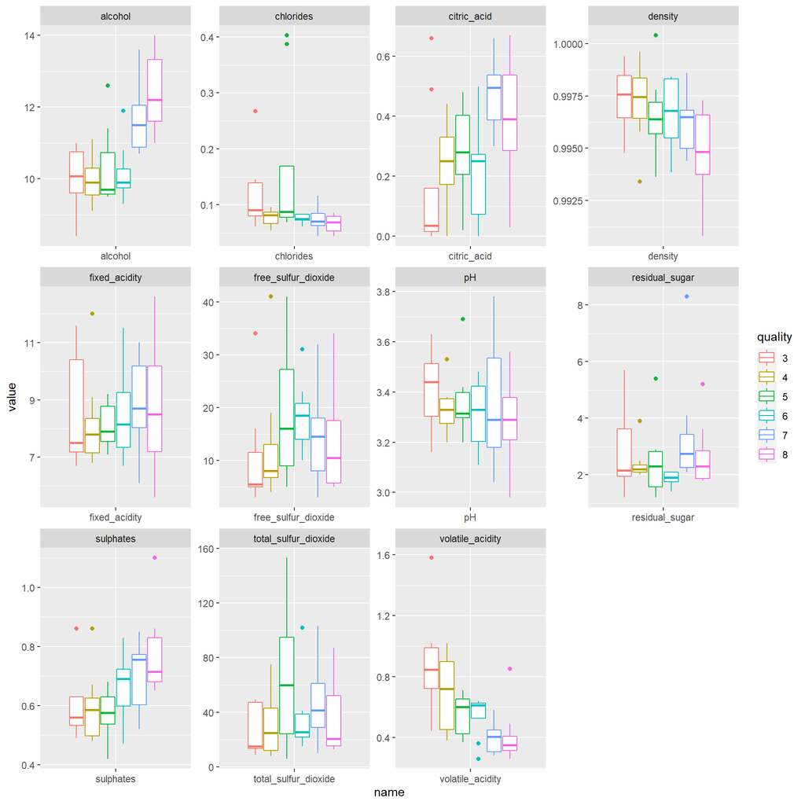

### 1.2. Scatter plot

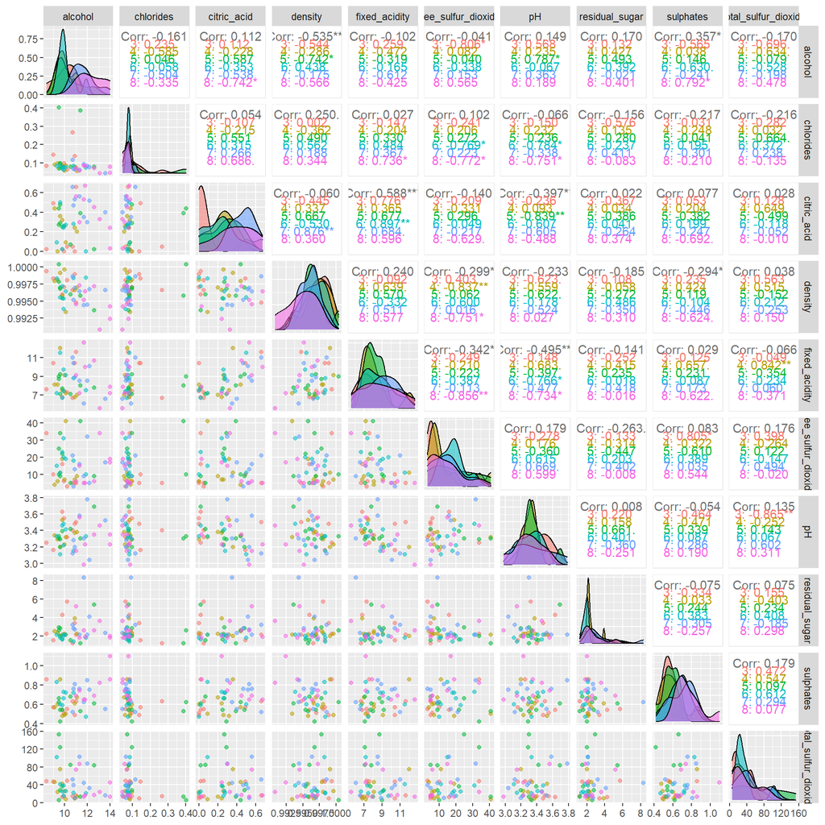

# ANOVA simple by variable

## col1

| name | term | sumsq | meansq | statistic | p.value | h0_param |
| --- | --- | --- | --- | --- | --- | --- |
| alcohol | quality | 42.625 | 8.525 | 9.099 | 0.000 | sign |
| alcohol | Residuals | 39.348 | 0.937 | NA | NA | NA |
| chlorides | quality | 0.055 | 0.011 | 2.471 | 0.047 | sign |
| chlorides | Residuals | 0.186 | 0.004 | NA | NA | NA |
| citric_acid | quality | 0.558 | 0.112 | 3.370 | 0.012 | sign |
| citric_acid | Residuals | 1.390 | 0.033 | NA | NA | NA |
| density | quality | 0.000 | 0.000 | 2.112 | 0.083 | no sign |
| density | Residuals | 0.000 | 0.000 | NA | NA | NA |
| fixed_acidity | quality | 3.244 | 0.649 | 0.216 | 0.954 | no sign |
| fixed_acidity | Residuals | 126.381 | 3.009 | NA | NA | NA |
| free_sulfur_dioxide | quality | 460.354 | 92.071 | 0.827 | 0.538 | no sign |
| free_sulfur_dioxide | Residuals | 4675.625 | 111.324 | NA | NA | NA |
| pH | quality | 0.074 | 0.015 | 0.514 | 0.764 | no sign |
| pH | Residuals | 1.215 | 0.029 | NA | NA | NA |
| residual_sugar | quality | 10.875 | 2.175 | 1.272 | 0.294 | no sign |
| residual_sugar | Residuals | 71.838 | 1.710 | NA | NA | NA |
| sulphates | quality | 0.238 | 0.048 | 3.278 | 0.014 | sign |
| sulphates | Residuals | 0.609 | 0.015 | NA | NA | NA |
| total_sulfur_dioxide | quality | 8489.104 | 1697.821 | 1.572 | 0.189 | no sign |
| total_sulfur_dioxide | Residuals | 45374.875 | 1080.354 | NA | NA | NA |
| volatile_acidity | quality | 1.334 | 0.267 | 5.978 | 0.000 | sign |
| volatile_acidity | Residuals | 1.874 | 0.045 | NA | NA | NA |

## 3. ANOVA simple by variable

### 1. Alcohol

#### a. Compare between residuals and fitted

```
            Df Sum Sq Mean Sq F value   Pr(>F)
quality      5  42.62   8.525   9.099 6.38e-06 ***
Residuals   42  39.35   0.937
---
Signif. codes:  0 '***' 0.001 '**' 0.01 '*' 0.05 '.' 0.1 ' ' 1
```

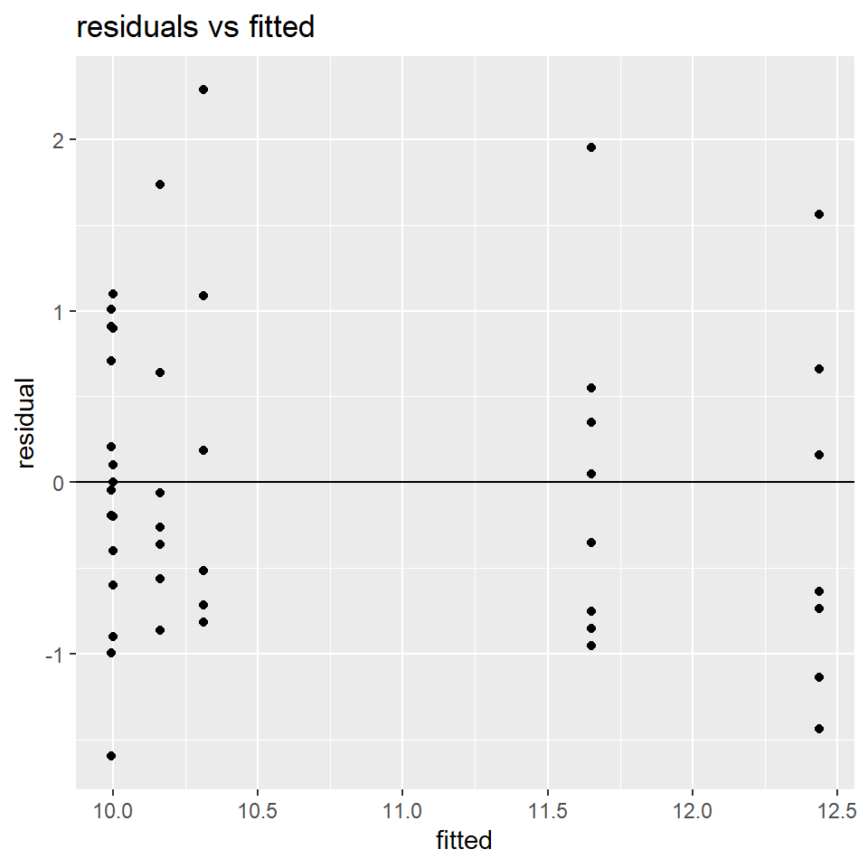

#### b.Normal

```
    Shapiro-Wilk normality test

data:  model1$residuals
W = 0.95384, p-value = 0.05693
```

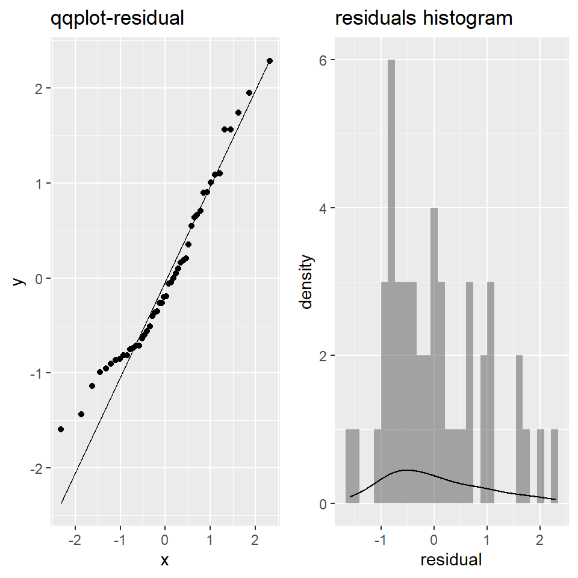

#### c. Homogeneity of variance

```
    Bartlett test of homogeneity of variances

data:  value by quality
Bartlett's K-squared = 2.4531, df = 5, p-value = 0.7835
```

### 2. Sulphates

#### a. Compare between residuals and fitted

```
            Df Sum Sq Mean Sq F value Pr(>F)
quality      5 0.2377 0.04755   3.278 0.0137 *
Residuals   42 0.6092 0.01451
---
Signif. codes:  0 '***' 0.001 '**' 0.01 '*' 0.05 '.' 0.1 ' ' 1
```

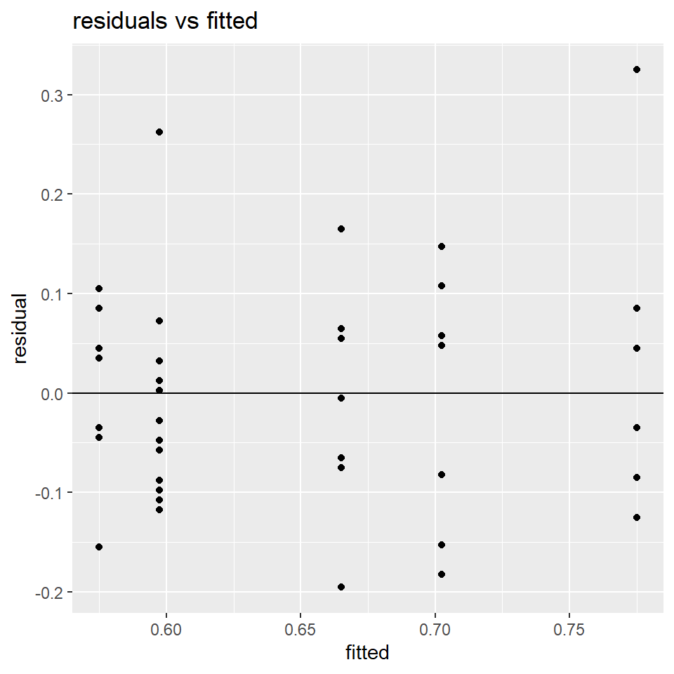

#### b.Normal

```
    Shapiro-Wilk normality test

data:  model2$residuals
W = 0.95443, p-value = 0.06013
```

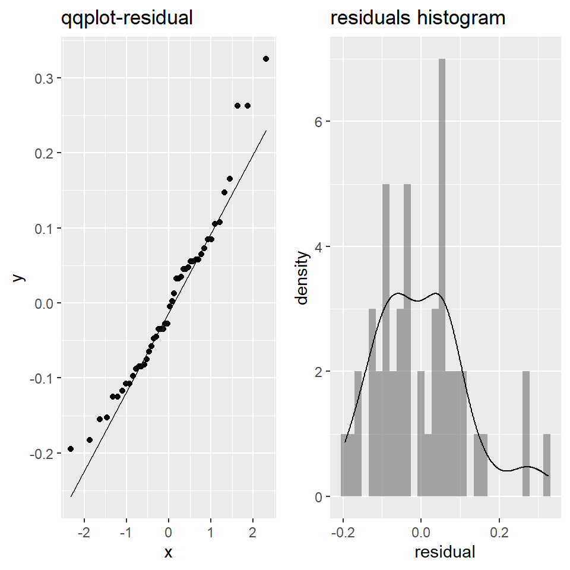

#### c. Homogeneity of variance

```
    Bartlett test of homogeneity of variances

data:  value by quality
Bartlett's K-squared = 2.3066, df = 5, p-value = 0.8053
```

### 3. Volatile_acidity

#### a. Compare between residuals and fitted

```
            Df Sum Sq Mean Sq F value   Pr(>F)
quality      5  1.334 0.26678   5.978 0.000291 ***
Residuals   42  1.874 0.04463
---
Signif. codes:  0 '***' 0.001 '**' 0.01 '*' 0.05 '.' 0.1 ' ' 1
```

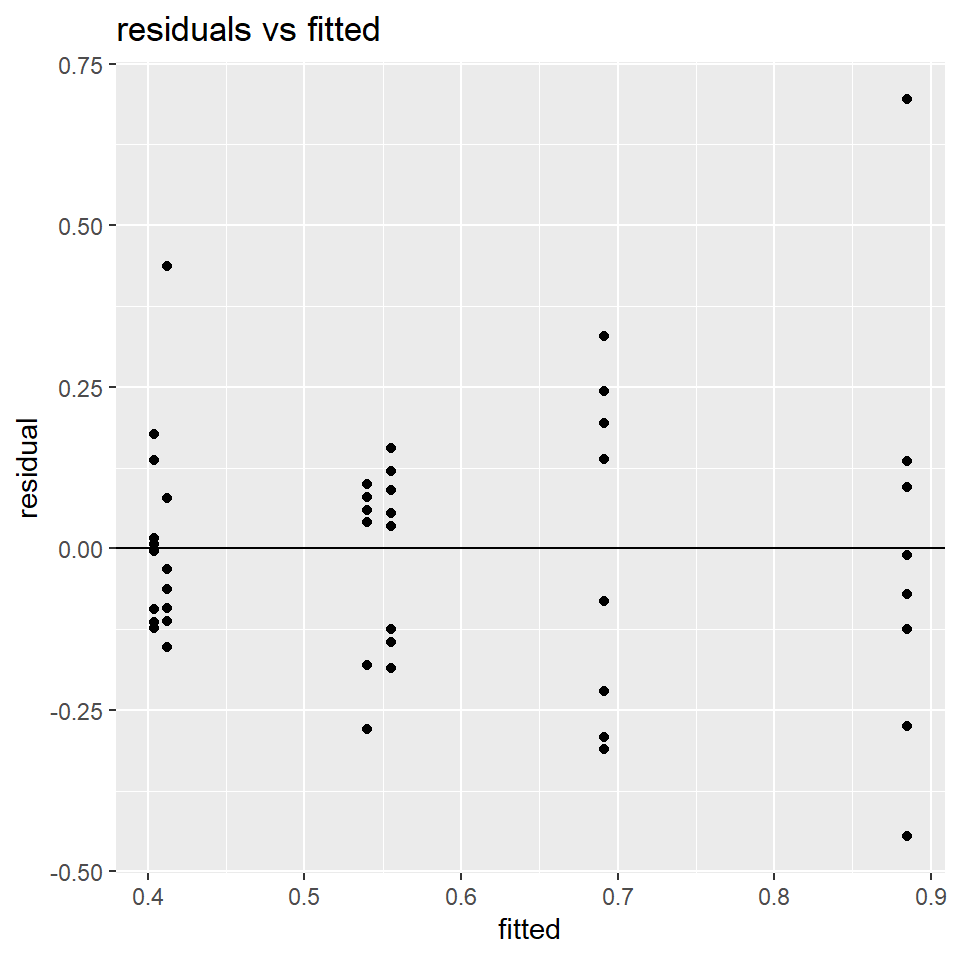

#### b.Normal

```
    Shapiro-Wilk normality test

data:  model3$residuals
W = 0.95532, p-value = 0.06534
```

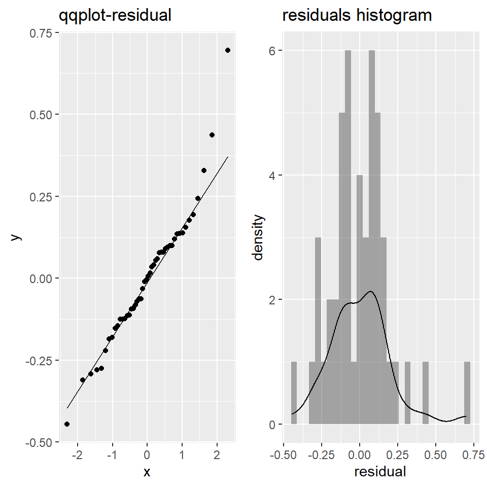

#### c. Homogeneity of variance

```
    Bartlett test of homogeneity of variances

data:  value by quality
Bartlett's K-squared = 12.245, df = 5, p-value = 0.03158
```

### 4. chlorides

#### a. Compare between residuals and fitted

```
            Df Sum Sq  Mean Sq F value Pr(>F)
quality      5 0.0546 0.010920   2.471 0.0475 *
Residuals   42 0.1856 0.004419
---
Signif. codes:  0 '***' 0.001 '**' 0.01 '*' 0.05 '.' 0.1 ' ' 1
```

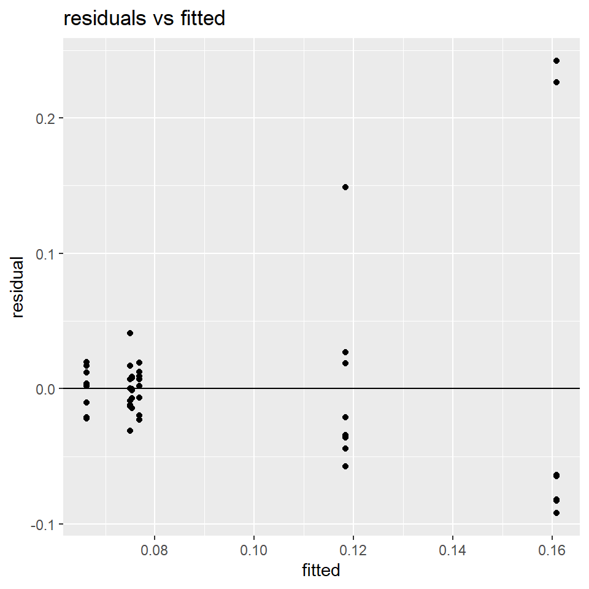

#### b.Normal

```
    Shapiro-Wilk normality test

data:  model3$residuals
W = 0.73557, p-value = 5.974e-08
```

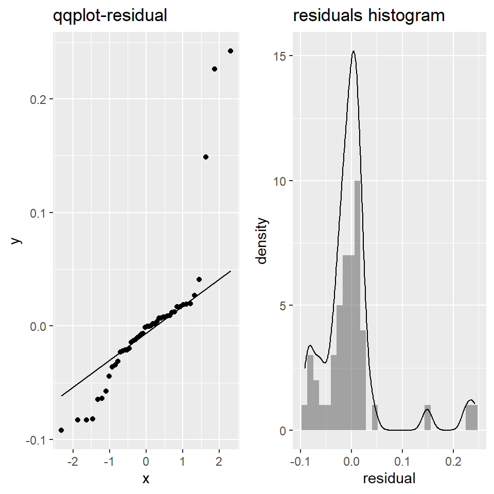

#### c. Homogeneity of variance

```
    Bartlett test of homogeneity of variances

data:  value by quality
Bartlett's K-squared = 70.422, df = 5, p-value = 8.37e-14
```

### 5. citric_acid

#### a. Compare between residuals and fitted

```
            Df Sum Sq Mean Sq F value Pr(>F)
quality      5 0.5577 0.11153    3.37  0.012 *
Residuals   42 1.3900 0.03309
---
Signif. codes:  0 '***' 0.001 '**' 0.01 '*' 0.05 '.' 0.1 ' ' 1
```

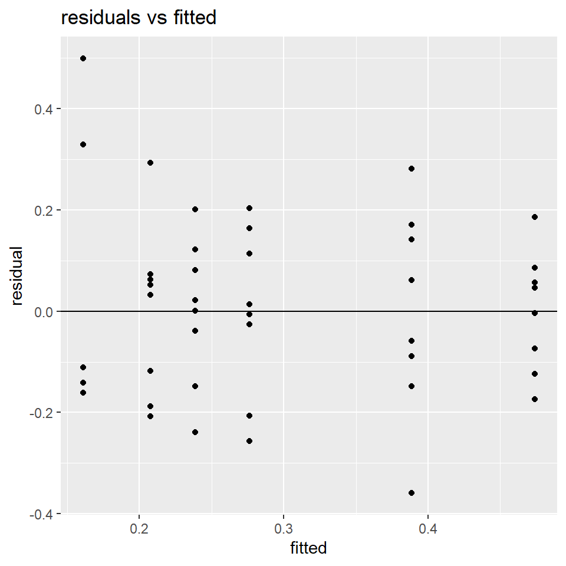

#### b.Normal

```
    Shapiro-Wilk normality test

data:  model3$residuals
W = 0.97913, p-value = 0.5429
```

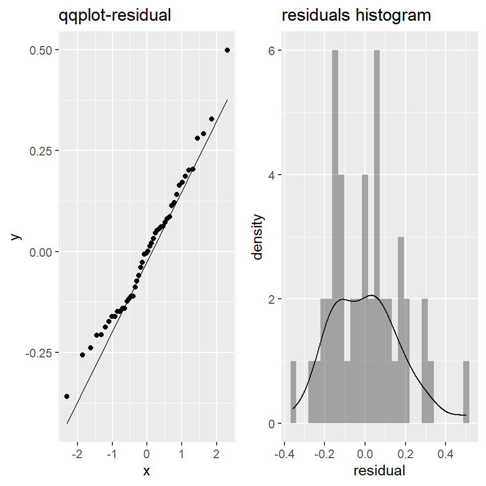

#### c. Homogeneity of variance

```
    Bartlett test of homogeneity of variances

data:  value by quality
Bartlett's K-squared = 5.1535, df = 5, p-value = 0.3974
```

# Block Experimental Design

## all results

### combination with normal residual

| name | combination | term | sumsq | meansq | statistic | p.value | h0_param | h0_residual |
| --- | --- | --- | --- | --- | --- | --- | --- | --- |
| 1 | fixed_acidity | bq | 0.001 | 0.001 | 0.002 | 0.966 | no sign | norm |
| 1 | alcohol | trt | 44.956 | 8.991 | 12.592 | 0.000 | sign | norm |
| 1 | fixed_acidity | bq | 1.101 | 1.101 | 44.093 | 0.000 | sign | norm |
| 1 | citric_acid | trt | 0.450 | 0.090 | 3.606 | 0.009 | sign | norm |
| 1 | fixed_acidity | bq | 0.000 | 0.000 | 27.867 | 0.000 | sign | norm |
| 1 | density | trt | 0.000 | 0.000 | 1.182 | 0.334 | no sign | norm |
| 1 | fixed_acidity | bq | 0.433 | 0.433 | 24.247 | 0.000 | sign | norm |
| 1 | pH | trt | 0.280 | 0.056 | 3.131 | 0.017 | sign | norm |
| 1 | fixed_acidity | bq | 60.750 | 60.750 | 0.241 | 0.626 | no sign | norm |
| 1 | total_sulfur_dioxide | trt | 2651.417 | 530.283 | 2.105 | 0.084 | no sign | norm |
| 1 | fixed_acidity | bq | 0.073 | 0.073 | 1.894 | 0.176 | no sign | norm |
| 1 | volatile_acidity | trt | 0.779 | 0.156 | 4.031 | 0.005 | sign | norm |
| 2 | volatile_acidity | bq | 0.152 | 0.152 | 0.102 | 0.752 | no sign | norm |
| 2 | alcohol | trt | 21.589 | 4.318 | 2.889 | 0.025 | sign | norm |
| 2 | volatile_acidity | bq | 0.400 | 0.400 | 15.447 | 0.000 | sign | norm |
| 2 | citric_acid | trt | 0.510 | 0.102 | 3.943 | 0.005 | sign | norm |
| 2 | volatile_acidity | bq | 0.000 | 0.000 | 0.192 | 0.664 | no sign | norm |
| 2 | density | trt | 0.000 | 0.000 | 1.215 | 0.320 | no sign | norm |
| 2 | volatile_acidity | bq | 1764.188 | 1764.188 | 1.818 | 0.185 | no sign | norm |
| 2 | total_sulfur_dioxide | trt | 5827.437 | 1165.487 | 1.201 | 0.326 | no sign | norm |
| 3 | citric_acid | bq | 0.002 | 0.002 | 0.002 | 0.966 | no sign | norm |
| 3 | alcohol | trt | 29.774 | 5.955 | 5.989 | 0.000 | sign | norm |
| 3 | citric_acid | bq | 0.000 | 0.000 | 3.893 | 0.055 | no sign | norm |
| 3 | density | trt | 0.000 | 0.000 | 0.698 | 0.628 | no sign | norm |
| 3 | citric_acid | bq | 51.460 | 51.460 | 25.095 | 0.000 | sign | norm |
| 3 | fixed_acidity | trt | 15.349 | 3.070 | 1.497 | 0.212 | no sign | norm |
| 3 | citric_acid | bq | 0.675 | 0.675 | 28.792 | 0.000 | sign | norm |
| 3 | pH | trt | 0.153 | 0.031 | 1.302 | 0.282 | no sign | norm |
| 3 | citric_acid | bq | 450.188 | 450.188 | 0.679 | 0.415 | no sign | norm |
| 3 | total_sulfur_dioxide | trt | 4139.854 | 827.971 | 1.250 | 0.304 | no sign | norm |

[output cut: 84 more lines]

## Details

### 1

```r
var_quality <- "fixed_acidity"
var_trt <- "citric_acid"
```

```
   quality value_category value
1        3        greater  0.49
2        3        greater  0.66
3        3        greater  0.00
4        3        greater  0.42
5        4        greater  0.00
6        4        greater  0.27
7        4        greater  0.36
8        4        greater  0.27
9        5        greater  0.00
10       5        greater  0.29
11       5        greater  0.05
12       5        greater  0.45
13       6        greater  0.12
14       6        greater  0.56
```

[output cut: 34 more lines]

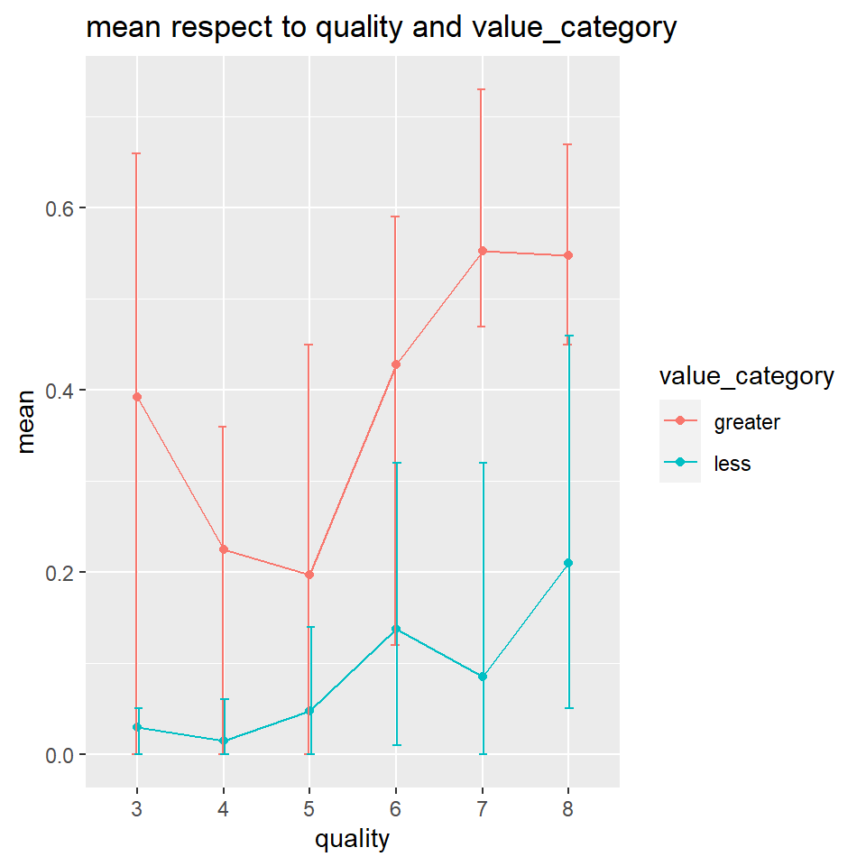

#### b. Summary of model

```
               Df Sum Sq Mean Sq F value   Pr(>F)
value_category  1 1.1011  1.1011  44.093 5.32e-08 ***
quality         5 0.4503  0.0901   3.606  0.00854 **
Residuals      41 1.0239  0.0250
---
Signif. codes:  0 '***' 0.001 '**' 0.01 '*' 0.05 '.' 0.1 ' ' 1
```

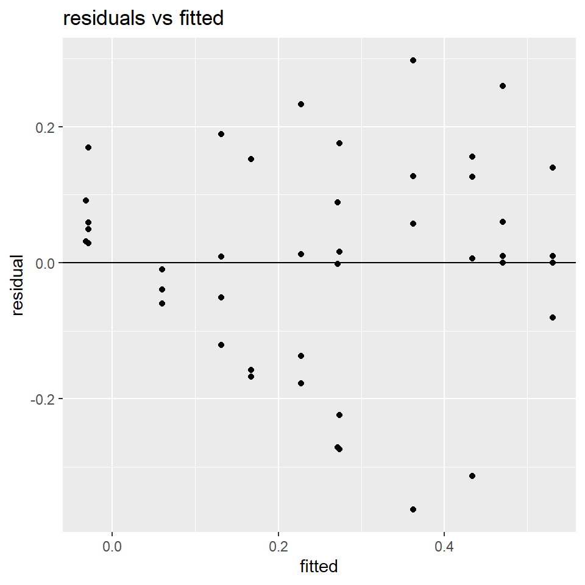

#### d. $H_0$ Normal residuals

```
    Shapiro-Wilk normality test

data:  model1$residuals
W = 0.96833, p-value = 0.2179
```

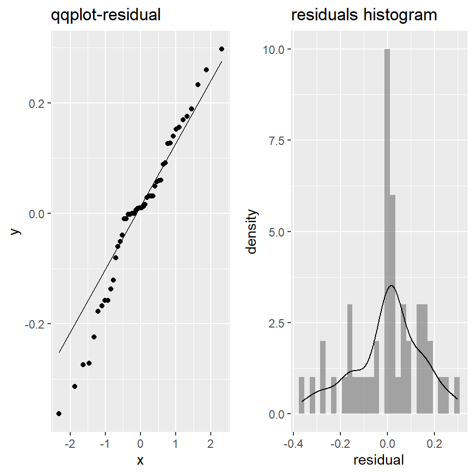

#### e. Homogeneity of variance

```
    Bartlett test of homogeneity of variances

data:  value by quality
Bartlett's K-squared = 3.8341, df = 5, p-value = 0.5735
```

```
    Bartlett test of homogeneity of variances

data:  value by value_category
Bartlett's K-squared = 6.956, df = 1, p-value = 0.008354
```

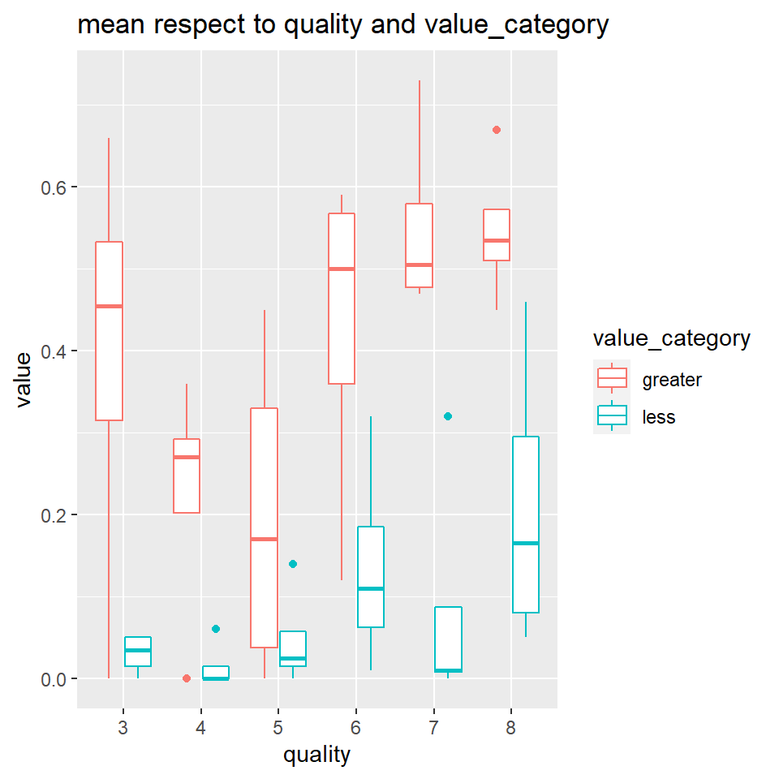

### 2

```r
var_quality <- "fixed_acidity"
var_trt <- "pH"
```

```
   quality value_category value
1        3        greater  3.48
2        3        greater  3.50
3        3        greater  3.25
4        3        greater  3.38
5        4        greater  3.37
6        4        greater  3.17
7        4        greater  3.26
8        4        greater  3.29
9        5        greater  3.15
10       5        greater  3.22
11       5        greater  3.13
12       5        greater  3.08
13       6        greater  3.14
14       6        greater  3.21
```

[output cut: 34 more lines]

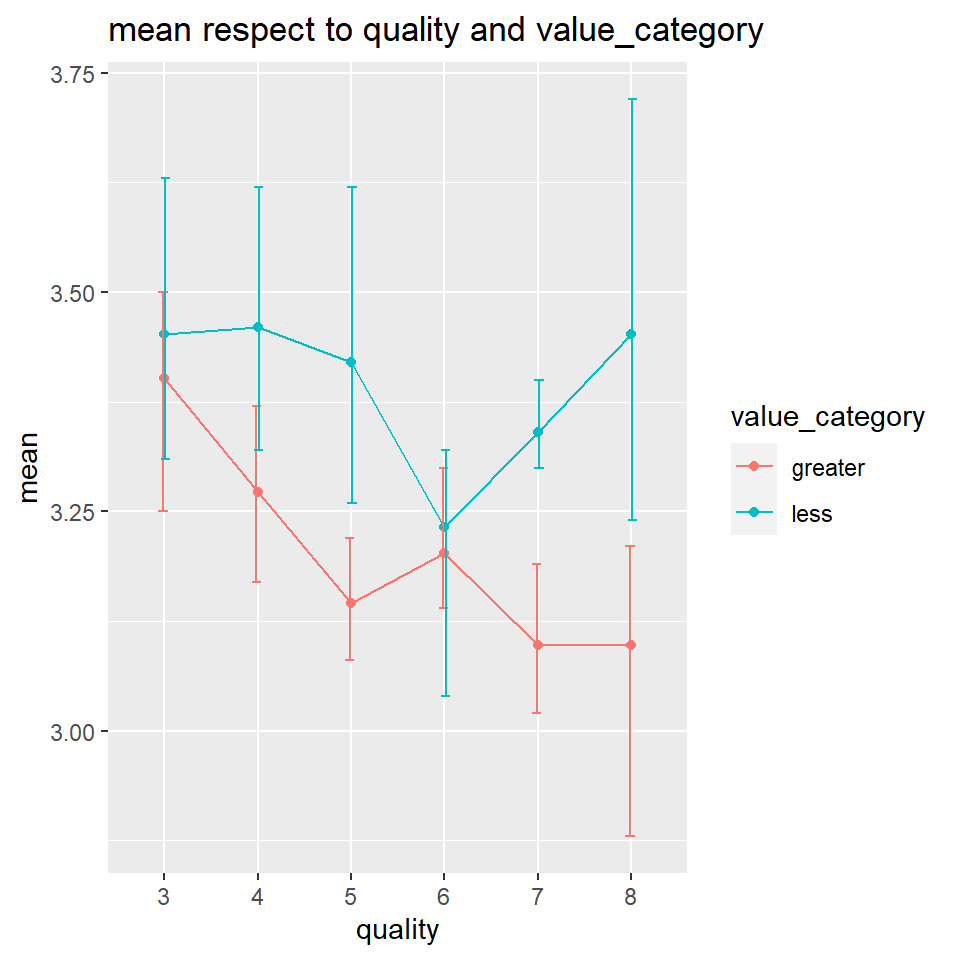

#### b. Summary of model

```
               Df Sum Sq Mean Sq F value   Pr(>F)
value_category  1 0.4332  0.4332  24.247 1.43e-05 ***
quality         5 0.2797  0.0559   3.131   0.0175 *
Residuals      41 0.7325  0.0179
---
Signif. codes:  0 '***' 0.001 '**' 0.01 '*' 0.05 '.' 0.1 ' ' 1
```

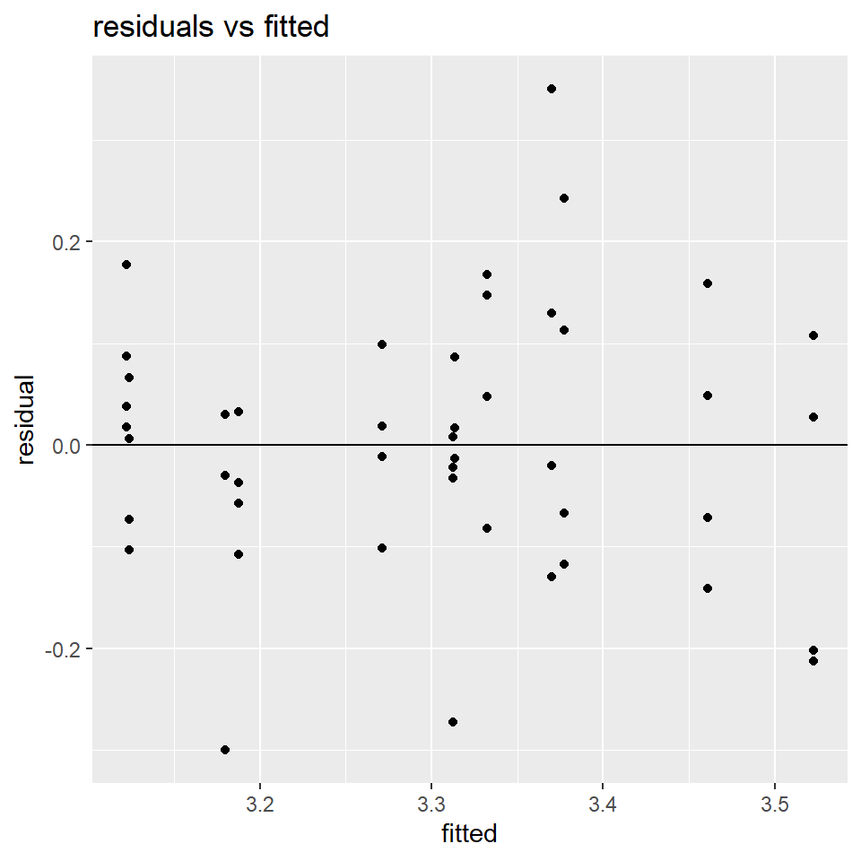

#### d. $H_0$ Normal residuals

```
    Shapiro-Wilk normality test

data:  model1$residuals
W = 0.98534, p-value = 0.805
```

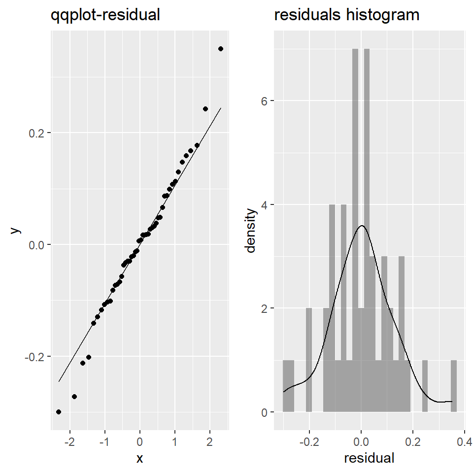

#### e. Homogeneity of variance

```
    Bartlett test of homogeneity of variances

data:  value by quality
Bartlett's K-squared = 7.1601, df = 5, p-value = 0.209
```

```
    Bartlett test of homogeneity of variances

data:  value by value_category
Bartlett's K-squared = 0.28333, df = 1, p-value = 0.5945
```

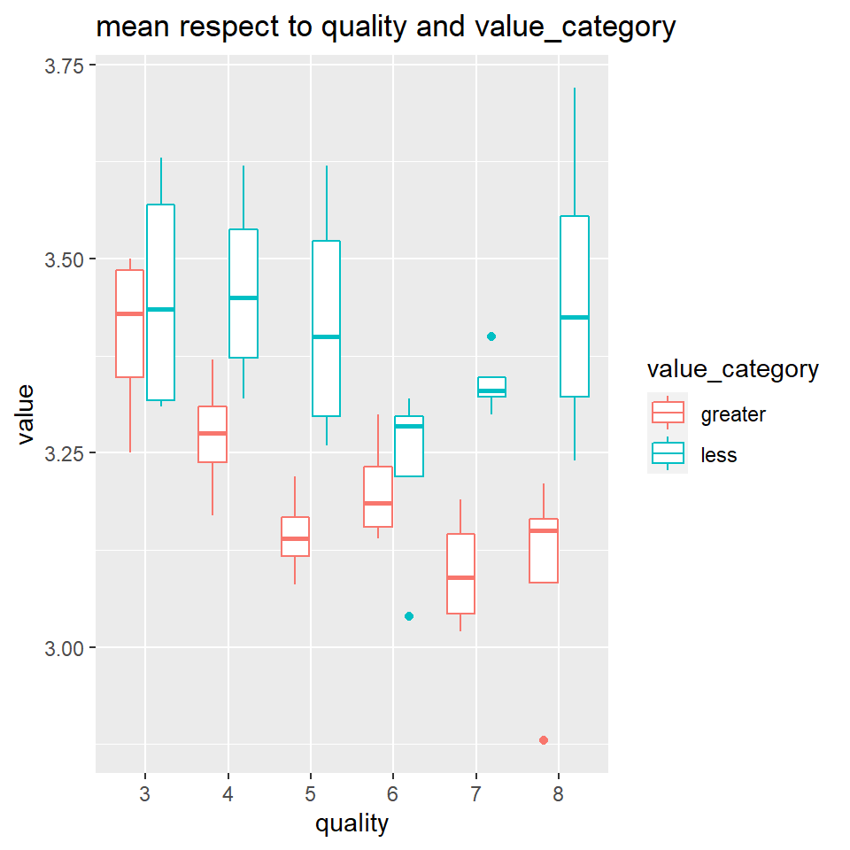